# Maximizing Elevation in the Himalayas

Carter Burr, Jack Schreuder, Alex Friedberg

2022-03-13

## Introduction

This analysis will focus on climbing data for a Himalyan Mountain called ‘Cho Oyu’. Cho Oyu is the sixth highest mountain on the planet, with a peak at 8188 meters above sea level. The reason we’ve chosen this peak is that it is considered to be one of the most accessible peaks in the Himalayas, and as such is a popular destination for climbers of many different skill levels. Note: referring to a 8000+ meter mountain as ‘accessible’ is a little bit of an oxymoron, but when compared to notoriously difficult mountains like K2 and Everest, the description is fairly accurate. The original data set is incredibly large, and contains data for many mountains, both hundreds of meter taller, and shorter than Cho Oyu. Choosing one mid-to-tall peak allows us to see the true effect of all the variables without being limited by the size of difficulty of other peaks. Additionally, Cho Oyu alone has more than enough data entries to make and educated conclusion about which factors most impact maximum height achieved.

### The Dataset

For our final project, we decided to use a dataset compiled by Alex Cookson, where he first posted it to his blog at https://www.alexcookson.com/post/analyzing-himalayan-peaks-first-ascents/ , which we were able to then later find in the tidytuesday github repository at https://github.com/rfordatascience/tidytuesday/blob/master/data/2020/2020-09-22/readme.md.

### Scientific Context

For mountain climbing enthusiasts, there is no greater story to tell than the one of how high they climbed in the Himalayan mountains. But climbing these uniquely enormous mountains is more than just pride, about one quarter of peaks in the Himalayan mountain range have never been climbed before. The human sense of adventure is insatiable, and not even the dangers of altitude sickness, extreme temperatures, and ever changing terrain can dissuade people from trying to climb up these mountains. Given the high level of danger and difficulty involved, it is important for climbers to understand factors that contribute to a successful climb, because if they don’t the trip could be deadly for them and their sherpas. So how do climbers achieve the highest height they can? That is what we aim to answer with our analysis of this data.

### Refining our data

After playing around with our data for some time, we realized that having every single mountain in our dataset was too many data points and produced jumbled up results due to the severe differences in the mountains. In order to solve this, we decided that we would refine our data down to just the expeditions held on 1 mountain, as it would better show us the impact each explanatory variable had. When it came down to what mountain to decide, we looked at how many datapoints they had, as well as the range of our numerical variables. For this, we decided to use mount Cho Oyu, as it had 1332 data points, a nice amount that was not too high nor too low. This mountain also had good variablity when it came to member size and numbers of hired staff, making it a safe pick to examine our results from.

### Codebook

| Name of Variable | Explanation |
| --- | --- |
| peak_name | The name (chr) of the peak that this expedition is climbing |
| year | The year (dbl) during which the expedition happened |
| season | The season the expedition happend in as a chr, either ‘Spring’, ‘Autumn’, ‘Winter’, or ‘Summer’ |
| highpoint_metres | A dbl expressing the highest point (in meters) the expedition reached before termination |
| members | A dbl showing the number of non-hired members in the expedition |
| member_death | The number (dbl) of members who died during the expedition |
| hired_staff | The number (dbl) of hired staff, aka sherpas, who went on the expedition |
| hired_staff_deaths | A dbl expressing the number of hired staff who died during the expedition |
| oxygen_used | A lgl variable where True means at least one member or hired staff used oxygen at any point, and False means that nobody ever used oxygen |
| trekking_agency | The chr name of trekking agency from which the hired staff where hired. Appears as NA if no staff were hired |

### Glimpse of our data

```
## Rows: 1,332
## Columns: 10
## $ peak_name          <chr> "Cho Oyu", "Cho Oyu", "Cho Oyu", "Cho Oyu", "Cho Oy~
## $ year               <dbl> 1988, 1988, 1988, 1988, 1988, 1988, 1988, 1988, 198~
## $ season             <chr> "Spring", "Spring", "Spring", "Spring", "Spring", "~
## $ highpoint_metres   <dbl> 7600, 7600, 8188, 8188, 8188, 8188, 5700, 8188, 650~
## $ members            <dbl> 5, 2, 4, 6, 8, 27, 2, 2, 6, 11, 11, 12, 11, 4, 6, 6~
## $ member_deaths      <dbl> 0, 0, 1, 0, 0, 0, 0, 0, 0, 0, 0, 0, 0, 0, 0, 0, 0, ~
## $ hired_staff        <dbl> 6, 0, 0, 1, 4, 0, 1, 0, 3, 5, 0, 0, 0, 2, 0, 2, 3, ~
## $ hired_staff_deaths <dbl> 0, 0, 0, 0, 0, 0, 0, 0, 0, 0, 0, 0, 0, 0, 0, 0, 0, ~
## $ oxygen_used        <lgl> FALSE, FALSE, FALSE, FALSE, FALSE, FALSE, FALSE, FA~
## $ trekking_agency    <chr> "Yeti Mountaineering & Trekking", NA, NA, "Atlas", ~
```

## Model Building

### Model Proposed by Carter

*This can be what we use for our 50-50 data split, we can change the seed as long as we keep it consistent.

### Model 1

#### Model Proposed by Carter

##### Picking the variables.

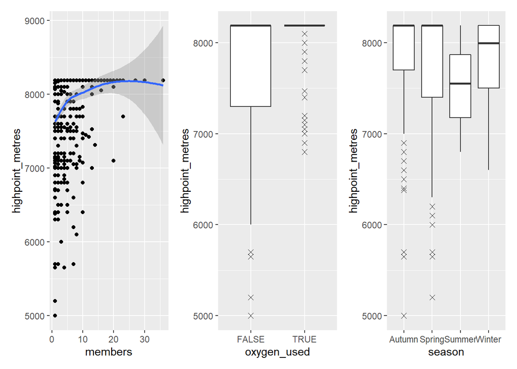

#### Interpretation

When deciding on what 3 explanatory variables I would be using for my model in order to best predict my response variable, I first started out with some background research to get a few ideas. First off, I looked at oxygen_used, and found many benefits to including the use of oxygen while reaching very high elevations. I also found research on the differences of climbing season. These looked like two very good categorical variables, I needed a numeric. To further look into this, I decided to make 3 seperate graphs with each of the variables I wished to use and saw how they individually looked against highpoint_metres. First off, I started with a point graph and looked at the correlation between members and highpoint, and saw that as the members increased the highpoint would also increase, but not by very much amount. Next, I looked at boxplots between if oxygen was used and its correlation to highpoint. Looking at this plot, we can clearly see that we would expect those who use oxygen to reach a higher point, as they appear to have an average and inter-quartile range much higher than those who do not use oxygen. Last off, I look at the effect season had on the high point, and saw some interesting results. First off, it appears we would get the highest on average with the least amount of range in Autumn. In spring the median is the same as autumn, but has more range in the 25%-50% quartile. Winter shows a slightly lower median, and then lastly we see summer with the lowest. These charts help us better understand what values and correlations to expect when we are making our model.

#### Making the model

```
## # A tibble: 6 x 5
##   term            estimate std.error statistic       p.value
##   <chr>              <dbl>     <dbl>     <dbl>         <dbl>
## 1 (Intercept)      7668.       36.0   213.     0
## 2 members            22.5       4.26    5.29   0.000000168
## 3 oxygen_usedTRUE   286.       47.3     6.04   0.00000000261
## 4 seasonSpring      -58.3      43.1    -1.35   0.177
## 5 seasonSummer     -245.      303.     -0.810  0.418
## 6 seasonWinter        5.47    187.      0.0293 0.977
```

```
## * NA -> ...1
```

```
## # A tibble: 666 x 2
##     pred highpoint_metres
##    <dbl>            <dbl>
##  1 7722.             7600
##  2 7655.             7600
##  3 7790.             8188
##  4 7718.             5700
##  5 7468.             8188
##  6 7803.             6500
##  7 7916.             7730
##  8 8143.             8188
##  9 7808.             8188
## 10 7745.             7600
## # ... with 656 more rows
```

```
## # A tibble: 1 x 2
##   r.squared adj.r.squared
##       <dbl>         <dbl>
## 1     0.123         0.117
```

```
## # A tibble: 1 x 3
##   .metric .estimator .estimate
##   <chr>   <chr>          <dbl>
## 1 rmse    standard        545.
```

#### Explanation:

##### Main Model Equation

Highpoint_metres = 7667.79 + 22.53*Memebers + 285.62*Oxygen_usedTRUE + 5.47*WinterYes - 58.25*SpringYes - 245.23*SummerYes

##### Main Model Interpretation:

When looking at the main model equation that we made, we can intrepet a few things. First off, our intercept is 7667.79, meainging if you put in 0 for all of the values, we would expect the climber to make it up to 7667.79 meters. Now when we look at memebers, we can see a coefficient of 22.53, meaning that with each member you add, you are expected to reach 22.53 meters higher on average. Although this does not seem very significant, some parties can have 30 to 40 members, which gives a huge boost to the height you would be expected to reach. Looking at the oxygen categorical variable, we can see that if you use oxygen you are expected to reach 285.62 meters higher on average, which is a pretty significant value. Looking at the seasons, we can see that it is using autumn as a baseline, so for that season you do not add or subtract anything. For the summer on average you would lose 245.23 meters on your high point, in the spring you would lose 58.25 meters on average for your high point, and finally in the winter you would expect to gain only 5 meters on average to your high point.

##### R^2 and RSME Values

Looking at our model, we get a R^2 value of 0.123, and an adjusted R^2 value of 0.117. These values are lower then what we would like to see, and it means that our indpendent variables have less correlation with the response variable than we would like. When we look at our RSME we get a value of 545.19. This value is a lot higher than we would like to see, as it shows us that we are experiencing a lot of error in our prediction model. Although this value is very high, when we look at the dataset, highpoint_metres is measured in thousands of meters, which is something we have to take into account when viewing this value. Although it is still higher than what we would like to see, it is not tremendously horrible when looking at the scale of the dataset.

### Model Proposed by Jack

#### New Calculated Variables for Modeling

#### Party Size Bootstrap Visual

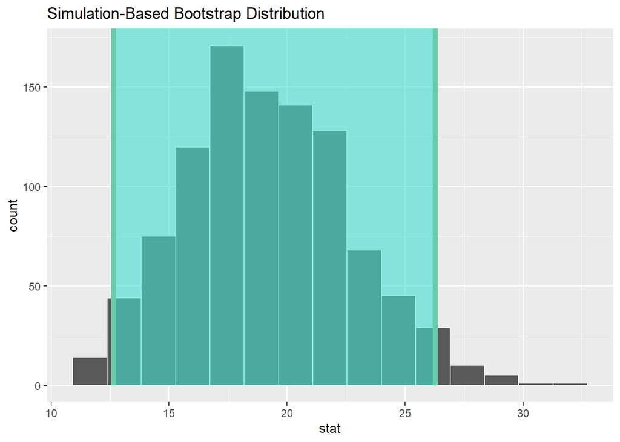

#### Model

```
## # A tibble: 6 x 5
##   term            estimate std.error statistic   p.value
##   <chr>              <dbl>     <dbl>     <dbl>     <dbl>
## 1 (Intercept)       7812.     108.      72.4   1.22e-312
## 2 party_size          18.3      3.01     6.10  1.84e-  9
## 3 trekUsed Agency    -64.1    104.      -0.617 5.38e-  1
## 4 seasonSpring       -87.2     44.0     -1.98  4.76e-  2
## 5 seasonSummer      -349.     314.      -1.11  2.67e-  1
## 6 seasonWinter      -101.     194.      -0.520 6.03e-  1
```

```
## # A tibble: 1 x 2
##   r.squared adj.r.squared
##       <dbl>         <dbl>
## 1    0.0637        0.0565
```

#### Model Evaluation

```
## * NA -> ...1
```

```
## Rows: 666
## Columns: 2
## $ pred             <dbl> 7862.786, 7761.830, 7945.238, 7766.646, 7500.385, 797~
## $ highpoint_metres <dbl> 7600, 7600, 8188, 5700, 8188, 6500, 7730, 8188, 8188,~
```

```
## # A tibble: 1 x 3
##   .metric .estimator .estimate
##   <chr>   <chr>          <dbl>
## 1 rmse    standard        564.
```

#### Justification and Explanation

The goal of this model is to predict how high a given expedition will reach using the number of people in the expedition, whether the expedition was conducted through a trekking agency, and what season the expedition took place during. Above you will see the bootstrap distribution of party_size, showing that there is a positive correlation between this metric and highpoint. Season is included due to the large significance of weather conditions on a climb, summer has a very different set of conditions than winter does. Additionally the trek variable shows whether a trekking agency was used or not, the presence (or absence) of experienced guides can have a large effect on the outcome of an expedition. The model is described as follows: highpoint (meters) = 7812 + 18.3(party size) - 64.1(if Used Agency) -87.2(if Spring) - 348.7(if Summer) - 100.8(if Winter). The RMSE of my model is 564.4 which indicates that there is a moderately large difference between the model’s prediction and the actual value. A few hundred meters on an 8000 meter mountain isn’t that big of a deal, but in a place as dangerous as the Himalayas even a centimeter counts.

### Model Proposed by Alex

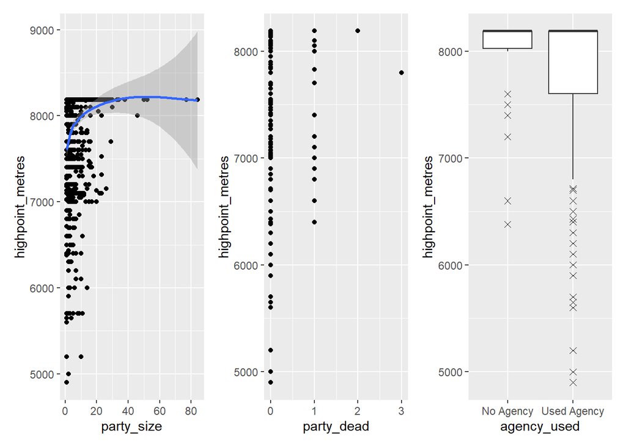

I created these graphs to explore different variables and combinations. I explored the data, and looked up some basic articles about expeditions to get an idea of what I should be looking for.

For my model, I chose to predict the highest point reached by using the variables of party_size (members + hired_staff). I chose to make this variable due to the common phrase “safety in numbers” and the data seems to show that is accurate.

#### Model

```
## # A tibble: 4 x 5
##   term                   estimate std.error statistic   p.value
##   <chr>                     <dbl>     <dbl>     <dbl>     <dbl>
## 1 (Intercept)              7847.     153.      51.4   2.40e-225
## 2 party_size                 15.9      2.87     5.53  4.65e-  8
## 3 party_dead               -109.     114.      -0.961 3.37e-  1
## 4 agency_usedUsed Agency    -84.7    154.      -0.550 5.82e-  1
```

```
## # A tibble: 1 x 2
##   r.squared adj.r.squared
##       <dbl>         <dbl>
## 1    0.0489        0.0443
```

#### Model Evaluation

```
## Rows: 622
## Columns: 2
## $ pred             <dbl> 7936.885, 7873.339, 7873.339, 7825.680, 7809.794, 780~
## $ highpoint_metres <dbl> 7600, 8188, 8188, 7400, 7600, 8188, 8188, 8188, 7200,~
```

```
## # A tibble: 1 x 3
##   .metric .estimator .estimate
##   <chr>   <chr>          <dbl>
## 1 rmse    standard        558.
```

#### Justification and Explanation

Our equation is relatively simple. For every member added to our group, we expect the highest point reached to increase by 15.9 meters. For every person to die on a trek, we expect the peak to decrease by 109 meters. If an agency was used, we expect the elevation to decrease a static 84.7 meters. This is an odd conclusion to reach for trekking agency, because we would assume that if an agency was used, we would achieve a higher elevation. However our data suggests otherwise.

### Model Choice

| Model | R^2 | RMSE |
| --- | --- | --- |
| Carter | 0.123 | 545.2 |
| Jack | 0.064 | 564.4 |
| Alex | 0.049 | 558.0 |

When examining at the different models as well as the R^2 and RMSE values, we decided that we would use data set #1 to use for the third part of this assignment. This model has the best fit to the data, and also can help us answer our scientific question of how can climbers achieve the highest height they can while climbing mountains. Apart from the metrics, the variables included in the model provide the most logical set of choices a prospective climber could make. Things like whether to use oxygen or not and what season to begin the expedition in are very tangible for climbers planning a trip, so it makes sense to use these easily controllable things in the model.

```
## # A tibble: 6 x 5
##   term            estimate std.error statistic  p.value
##   <chr>              <dbl>     <dbl>     <dbl>    <dbl>
## 1 (Intercept)       7699.      25.8    299.    0
## 2 members             18.4      3.09     5.95  3.48e- 9
## 3 oxygen_usedTRUE    298.      33.6      8.87  2.35e-18
## 4 seasonSpring       -83.6     31.4     -2.66  7.84e- 3
## 5 seasonSummer        50.4    202.       0.249 8.03e- 1
## 6 seasonWinter      -171.     155.      -1.10  2.72e- 1
```

```
## # A tibble: 1 x 2
##   r.squared adj.r.squared
##       <dbl>         <dbl>
## 1     0.111         0.107
```

##### Main Model Equation

Highpoint_metres = 7699.19 + 18.39*Memebers + 298.03*Oxygen_usedTRUE + 50.40*SummerYes - 83.56*SpringYes - 170.61*WinterYes

##### Main Model Interpretation:

When looking at the main model equation that we made, we can interpret a few things. First off, our intercept is 7699.19, meaning if you put in 0 for all of the values, we would expect the climber to make it up to 7699.19 meters. This number being so high can likely be explained by how high base camps are, as they do start at a very high elevation to begin with. Now when we look at our numerical variable of members, we can see a coefficient of 18.39, meaning that with each member you add, you are expected to reach 18.39 meters higher on average. Even though this value does not seem very significant at first, some parties can have 30 to 40 members, which can give a boost of hundreds of meters for climbers, helping them maximize their highpoint on the mountain. Next we look at the use of oxygen as a categorical variable, we can see that if you use oxygen you are expected to reach 298.03 meters higher on average, which provides a significant boost just with the use which should encourage climbers to invest in using oxygen if they are trying to achieve their maximum height. Next we can look at our next categorical variable which is the seasons. We can see that it is using autumn as a baseline, so for that season you do not add or subtract anything. For the winter on average you would lose 170.61 meters on your high point, in the spring you would lose 83.56 meters on average for your high point, and finally in the summer you would expect to gain only 50.40 meters on average to your high point.